# Using Optistock

The main point of the optistock package is to produce cost-per-fish (CPF) curves for determining how expensive it is to stock fish on any given day based on the management outcome. The model combines information from a species growth and natural mortality, as we well as hatchery rearing costs to determine the economically optimum time to stock fish that will result in the lowest cost.

A simple CPF curve might look something like the following:

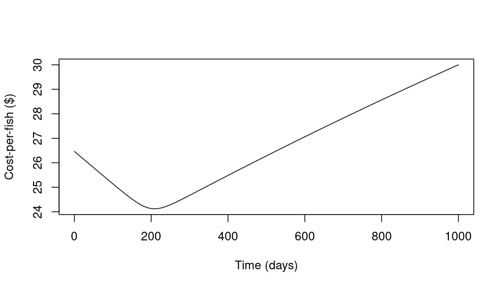

The code to produce the above curve is called with a single function that includes arguments for mortality and cost curves. Growth is used in the model to determine how long it will take for fish to get to a certain length. Here is the code that produced the above curve. While it may look unwieldy at first it is actually fairly concise once all the compoents are understood.

```r
curve(
  cost_per_fish(
    time_at_stocking = x,
    time_at_rec = 1000,
    n_recruits_desired = 200,
    cost_fun = linear_total_cost,
    cost_fun_args = list(int = 20, beta = 0.01),
    mort_fun = exp_mort,
    mort_fun_args = list(
      m_init = 0.001, m_inf = 0.0001, alpha = 0.05, t_scale = 200
    )
  ),
  0, 1000,
  xlab = "Time (days)", ylab = "Cost-per-fish ($)"
)
```

### Shiny App

You can create your own examples by calling `optistock_app()`, which will open a shiny application that allows you to adjust the model.

## Package Details

This package contains all the necessary functions to be able to compute cost-per-fish for different fish stocking scenarios so long as growth, mortality, and hatchery costs are known (or assumed). The model starts with a management objective of having a certain number of fish of a certain length in a waterbody at some point in the future. Starting there one can work backwards using a growth function to determine how long (on average) it will take fish to grow that long. Once the time-to-length is calculated a mortality function can be used to determine how many fish need to be stocked at any given time to result in the desired number of fish of length $L$ at recruitment time $t_R$.

## Growth functions

The growth functions in this package are used to determine how long it will take a fish to reach length $L$. There are both growth functions and inverse growth functions. Growth functions take an input of time $t$ and corresponding growth parameters (i.e. for von Bertalanffy – $L_{\infty}$, $k$, and $t_0$). The returned value is the length $L$ at time $t$.

Inverse growth functions take the same growth parameters as the corresponding growth function, but take a length $L$ and return the time $t$ that the average fish will reach that length.

### Growth Curve

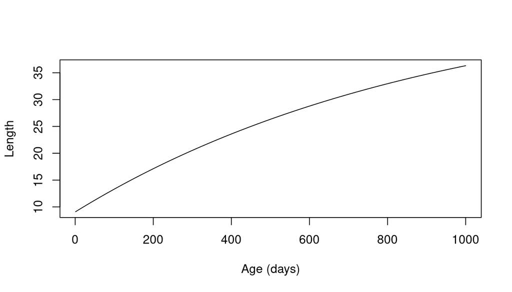

```r
time <- 1:1000
linf <- 50
k <- 0.4 / 365
t0 <- -0.5 * 365
len_at_age <- vbgf(time, linf, k, t0)
plot(len_at_age ~ time, type = "l", xlab = "Age (days)", ylab = "Length")
```

### Inverse Growth Curve

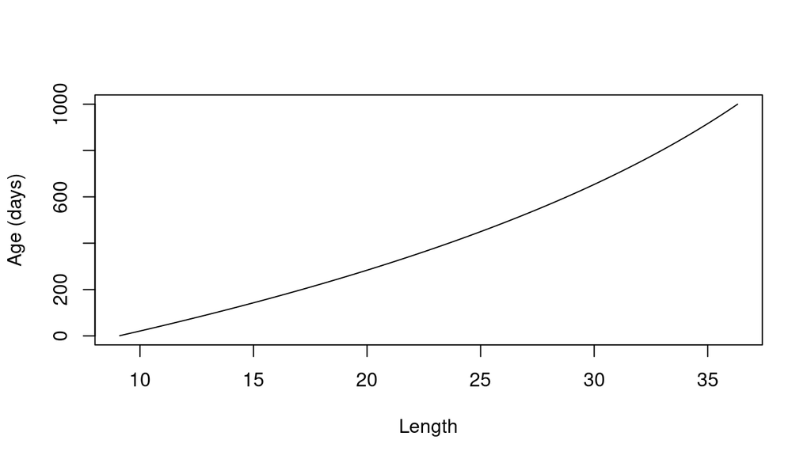

```r
age_at_len <- inv_vb(len_at_age, linf, k, t0)
plot(age_at_len ~ len_at_age, type = "l", xlab = "Length", ylab = "Age (days)")
```

## Mortality functions

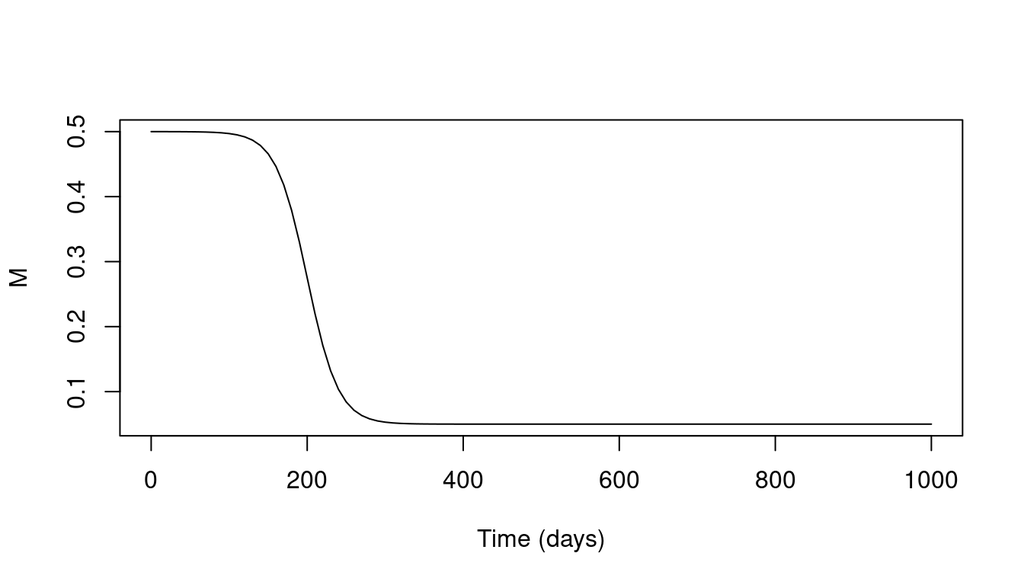

```r
curve(
  exp_mort(x, m_init = 0.5, m_inf = 0.05, alpha = 0.05, t_scale = 200),
  0, 1000,
  xlab = "Time (days)", ylab = "M"
)
```

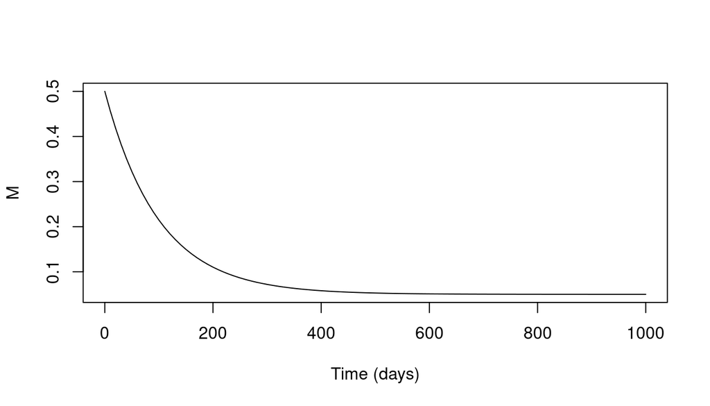

```r
curve(
  decreasing_mort(x, m_init = 0.5, m_inf = 0.05, alpha = 0.99),
  0, 1000,
  xlab = "Time (days)", ylab = "M"
)
```

## Cost functions

There are two types of cost functions available to calculate total costs to raise fish to a certain day. One is a linearly increasing function where total costs increase at a constant rate across time. The other is an exponentially increasing function where the total cost increases at a greater rate as time goes along. In both cases the cost can be made to increase exponentially along with the number of recruits raise if that behavior is so desired.

### Linear total cost

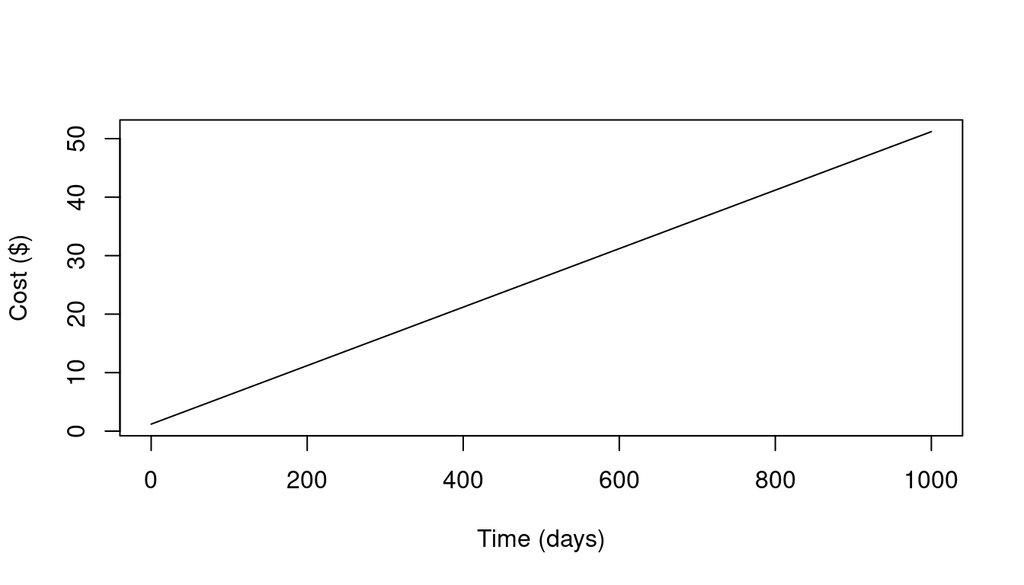

```r
recruits <- 1
int <- 1.2
beta <- 0.05
curve(
  linear_total_cost(x, recruits, int, beta),
  0, 1000,
  xlab = "Time (days)", ylab = "Cost ($)"
)
```

### Exponential Total Cost

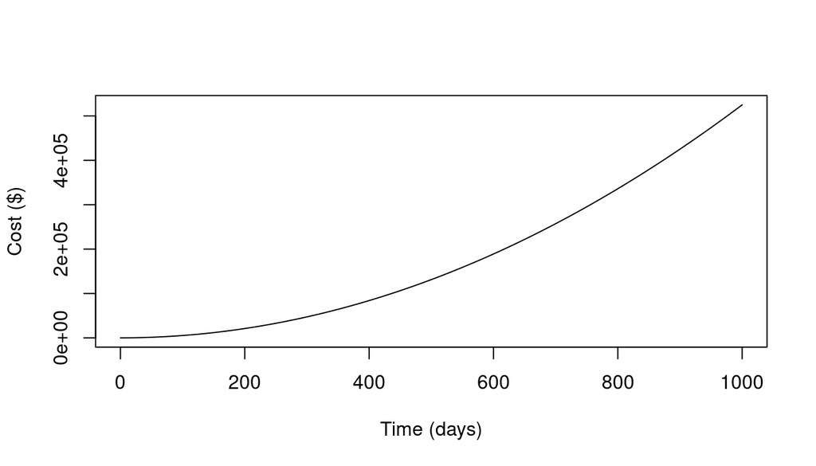

```r
init_cost <- 0.01
time_slope <- 0.01
time_exp <- 1.05
rec_slope <- 1
rec_exp <- 1
curve(
  total_daily_cost(x, recruits, init_cost, time_slope, time_exp, rec_slope, rec_exp),
  0, 1000,
  xlab = "Time (days)", ylab = "Cost ($)"
)
```